# Factors That Affect Car Mileage

Residual Plot and Summary

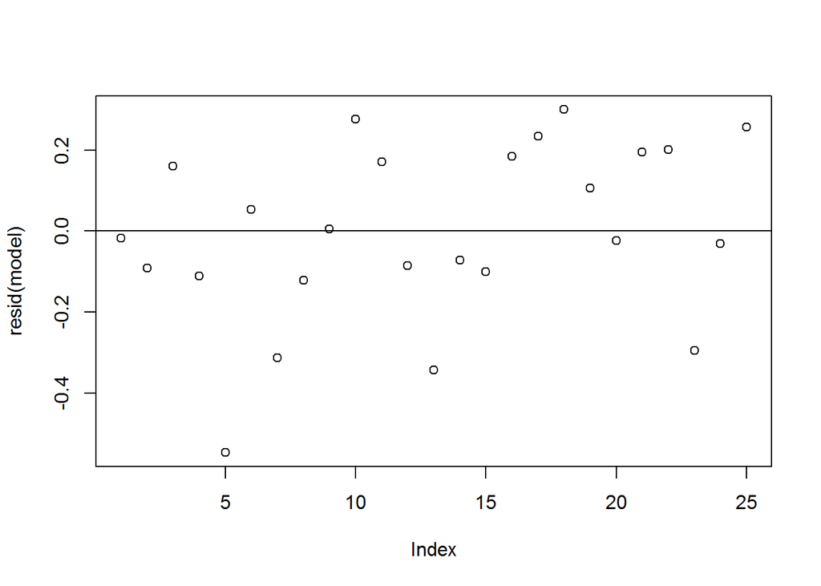

```r
# Residual plot
plot(resid(model))
abline(h=0)
```

```r
# Model Summary
summary(model)
```

```
##
## Call:
## lm(formula = Transmission ~ ., data = dfT)
##
## Residuals:
##     Min      1Q  Median      3Q     Max
## -0.5473 -0.1000 -0.0169  0.1851  0.3003
##
## Coefficients:
##                   Estimate Std. Error t value Pr(>|t|)
## (Intercept)       4.238991   2.651330    1.60    0.132
## MilePerGallon     0.028034   0.026063    1.08    0.300
## NumOfCyclinders  -0.100869   0.145680   -0.69    0.500
## Displacement     -0.002094   0.002341   -0.89    0.386
## HorsePower       -0.000736   0.003261   -0.23    0.825
## RearAxleRatio     0.193271   0.275088    0.70    0.494
## Weight            0.243299   0.263951    0.92    0.372
## qsec             -0.199716   0.086435   -2.31    0.037 *
## `V/S`            -0.103303   0.268882   -0.38    0.707
## NumOfFowardGears  0.018310   0.231432    0.08    0.938
## NumOfCarburetors -0.042174   0.129392   -0.33    0.749
## ---
## Signif. codes:  0 '***' 0.001 '**' 0.01 '*' 0.05 '.' 0.1 ' ' 1
##
## Residual standard error: 0.284 on 14 degrees of freedom
## Multiple R-squared:  0.812,  Adjusted R-squared:  0.677
## F-statistic: 6.03 on 10 and 14 DF,  p-value: 0.00136
```

```r
# The totoal residual error
deviance(model)
```

```
## [1] 1.131
```

For the coefficients, the column labeled Estimate contains the estimated regression coefficients as calculated by ordinary least squares.Theoretically, if a variable’s coefficient is zero then the variable is worthless; it adds nothing to the model. In our case, the estimate for ‘MilePerGallon’ is 0.028 and hence it does add some value to the model. Concretly speaking, we estimate the mileage to increase if the transmission is switched to manual.

R2 is a measure of the model’s quality. Bigger is better. Mathematically, it is the fraction of the variance of y that is explained by the regression model. The remaining variance is not explained by the model, so it must be due to other factors. In our case, the model explains 0.812 (81.2%) of the variance of model, which is surprisingly good.

**Model B Results**

Residual Plot and Summary

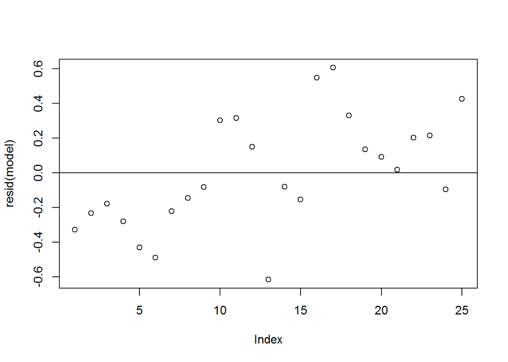

```r
# Residual plot
plot(resid(model))
abline(h=0)
```

```r
# Model Summary
summary(model)
```

```
##
## Call:
## lm(formula = Transmission ~ MilePerGallon + NumOfCyclinders +
##     HorsePower + Weight, data = dfT)
##
## Residuals:
##     Min      1Q  Median      3Q     Max
## -0.6154 -0.2225 -0.0805  0.2150  0.6049
##
## Coefficients:
##                 Estimate Std. Error t value Pr(>|t|)
## (Intercept)      1.67558    1.09618    1.53     0.14
## MilePerGallon    0.02498    0.02747    0.91     0.37
## NumOfCyclinders -0.07502    0.09483   -0.79     0.44
## HorsePower       0.00266    0.00316    0.84     0.41
## Weight          -0.22528    0.15233   -1.48     0.15
##
## Residual standard error: 0.352 on 20 degrees of freedom
## Multiple R-squared:  0.587,  Adjusted R-squared:  0.505
## F-statistic: 7.12 on 4 and 20 DF,  p-value: 0.000982
```

```r
# The totoal residual error
deviance(model) # residual sum of squares
```

```
## [1] 2.475
```

In model B, the sum of residual is pretty high 2.475. Also, R2 is 0.587, which means that this model only explains 59% of the variance. This in fact explains that all of the factors has to be consider to precisely understand why mileage varies.

### Appendix

#### Figure 2

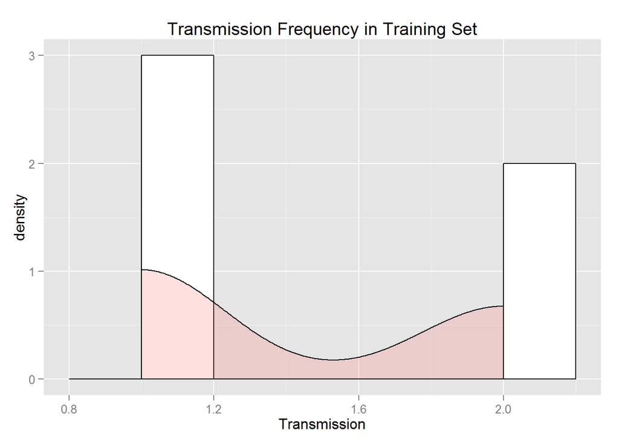

```r
#~~~~~ frequency
ggplot(dfT, aes(x=Transmission)) + geom_histogram(aes(y=..density..),binwidth=.2, colour="black", fill="white") +
  ggtitle("Transmission Frequency in Training Set") +
  geom_density(alpha=.2, fill="#FF6666")
```

#### Figure 3

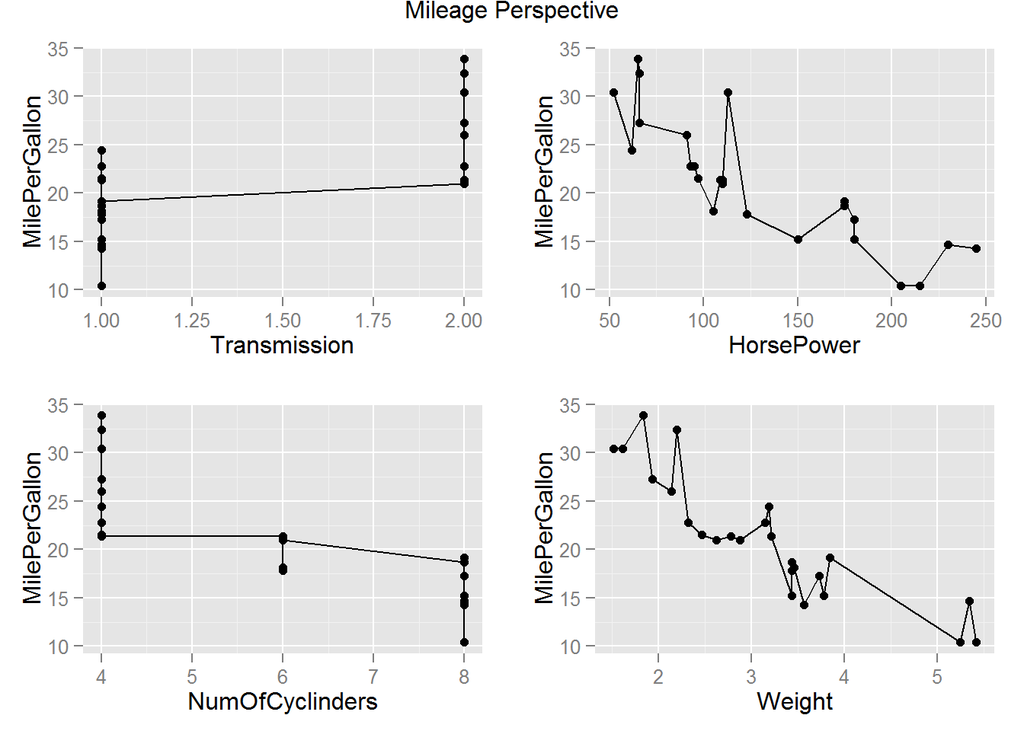

```r
#~~~ boxplot
b1 = ggplot(dfT, aes(x=Transmission, y=MilePerGallon)) + geom_line() + geom_point()
b2 = ggplot(dfT, aes(x=HorsePower, y=MilePerGallon)) + geom_line() + geom_point()
b3 = ggplot(dfT, aes(x=NumOfCyclinders, y=MilePerGallon)) + geom_line() + geom_point()
b4 = ggplot(dfT, aes(x=Weight, y=MilePerGallon)) + geom_line() + geom_point()

grid.arrange(b1, b2, b3, b4, main = "Mileage Perspective") # notice the outliers; hoping PCA processing should smooth that out.
```